### Analysis of the Vitamin C effect on Tooth Growth in Guinea Pigs

##### Jean-Michel Coeur, Statistical Inference Project 2, 3 April 2016

### 1. Overview

In an experiement with guinea pigs, each guinea pig received one of three dose levels of vitamin C by one of two delivery methods: either through Orange Juice or through Ascorbic Acid. At the end of the experiement, we measured their tooth growth.

In this analysis, we will investigate the effect of Vitamin C on Tooth Growth in Guinea Pigs and answer specifically to the following question: Do the delivery method and/or dosage affect the tooth growth in Guinea Pigs?

To perform this analysis, we use data from the R dataset `ToothGrowth`, which contain the result of the experiment. This code book describes the analysis process and the results obtained at each step to reach to the conclusions.

### 2. Data summary

At a glance, we look at:

- The Number of observations,
- Number and type of variables,
- Missing values,
- Range of results.

#### Exploratory analysis details: please see the paragraph 7.2 of the appendix.

- From the exploratory analysis, we discovered 60 observations, corresponding to 60 Guinea Pigs, and 3 variables:
  - “len”: length of odontoblasts (cells responsible for tooth growth): response of the experiment
  - “supp”: delivery methods: OJ (Orange Juice) or VC (ascorbic acid, which is a form of vitamin C).
  - “dose”: 0.5, 1, and 2 mg/day

We have an identical number of guinea pigs (10) who received a given dose (either 0.5, 1 or 2 mg/day) in a given delivery method: Orange Juice or Vitamin C (ascorbic acid).

To get an idea about the data, we plot the length of the tooths in comparison to the doses, and delivery methods. We use boxplots to get a sense of tooth lengh range per dose and delivery method.

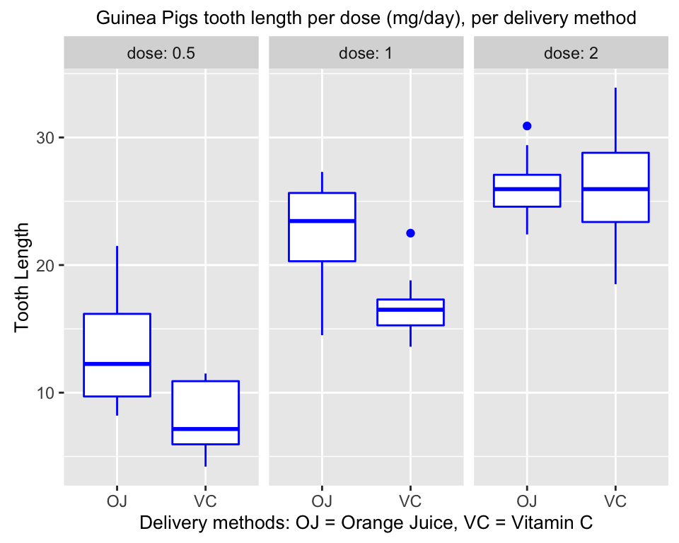

From the graph, we can draw two empiric hypothesis, which we will test further in this paper:

- Hypothesis 1: The dose amount affects positively the tooth growth, regardless of the delivery method.
- Hypothesis 2: The Orange Juice (OJ) affects positively the tooth growth, compare to the Vitamin C (VC).

### 3. Assumptions

- We consider that each group of guinea pig is normally distributed.
- We consider each group independent, with unequal variance, and not paired, because each guinea pig receives a single treatment with a single delivery method.

### 4. Hypothesis 1 - The dose amount affects positively the tooth growth

- Null hypothesis H0: Guinea Pigs tooth length with dose = x > Guinea Pigs tooth length with dose = y
- We compare each group of 20 pigs who received 0.5, 1 or 2 mg/day.
- Because the size of the groups are rather small, we perform a Student Test ( t = (X’-mu)/(s/sqrt(n)) ) on two of the three groups at a given time. We use the R function `t.test()`.
- We consider a confidence interval of 95% with one side-test and we look at the p-value to accept or reject the null hypothesis. if p-value < 5%, we fail to reject the null hypothesis.

See Apendix 7.4 for the corresponding R code.

| Test | P-Value |
| --- | --- |
| Dose 1 mg > 0.5 mg | 6.34e-08 |
| Dose 2 mg > 0.5 mg | 0 |
| Dose 2 mg > 1 mg | 9.5321e-06 |

Each P-Value is largely lower than 5%. We fail to reject the null hypothesis. Therefore, the dosage does affect positively the tooth growth in the guinea pigs. Because the dosage has such impact, we will test the second hypothesis below, knowing the dose amount.

### 5. Hypothesis 2 - The Orange Juice (OJ) affects positively the tooth growth, compare to the Vitamin C

- Null hypothesis H0: Guinea Pigs tooth length who had Orange Juice > Guinea Pigs tooth length who had Vitamin C
- We compare each group of 10 pigs who received Orange Juice or Vitamin C, in quantity of 0.5, 1 or 2 mg/day.
- Because the size of the groups are rather small, we perform a Student Test ( t = (X’-mu)/(s/sqrt(n)) ) to compare groups. We use the R function `t.test()`.
- At a given time, we compare two groups who received the same dose.
- We consider a confidence interface of 95% with one side-test and we look at the p-value to accept or reject the null hypothesis. if p-value < 5%, we fail to reject the null hypothesis.

See Apendix 7.5 for the corresponding R code.

| Test | P-Value |
| --- | --- |
| Dose 0.5 mg: Orange Juice > Vitamin C | 0.0031793034 |
| Dose 1 mg: Orange Juice > Vitamin C | 0.0005191879 |
| Dose 2 mg: Orange Juice > Vitamin C | 0.5180742056 |

### 6. Conclusions

Yes, delivery methods and dosage affect tooth growth in guinea pig:

Overal, the impact of Vitamin C is unconclusive. We would need more data, perhaps results with an higher dosage to draw a more precise conclusion.

### 7. Appendix

#### 7.1. Environment in use for the analysis

- R libraries in use.

```r
# Required R packages to perform the analysis
require(datasets)   # Load various datasets including the ToothGrowth dataset
require(ggplot2)    # Plotting system in use for the analysis
require(knitr)      # Results Test formatting
```

#### 7.2. Exploratory analysis

- R Functions used to perform Exploratory analysis.

```r
# To facilitate the manipulation of the dataset, we assign it to the variable 'tg'
tg <- ToothGrowth

# str() provides a good overview of the dataset
str(tg)
```

```
## 'data.frame':    60 obs. of  3 variables:
##  $ len : num  4.2 11.5 7.3 5.8 6.4 10 11.2 11.2 5.2 7 ...
##  $ supp: Factor w/ 2 levels "OJ","VC": 2 2 2 2 2 2 2 2 2 2 ...
##  $ dose: num  0.5 0.5 0.5 0.5 0.5 0.5 0.5 0.5 0.5 0.5 ...
```

```r
# Number of doses and number of pigs who received these doses in each delivery method
table(tg$dose, tg$supp)
```

```
##
##       OJ VC
##   0.5 10 10
##   1   10 10
##   2   10 10
```

```r
# Range of Tooth Growth to get some perspective
range(tg$len)
```

```
## [1]  4.2 33.9
```

#### 7.3 Distribution of guinea pig tooth growth per dosage and delivery method

- R Functions used to display the distribution of guinea pigs tooth length per dosage and per delivery method.

```r
tg$dose <- factor(tg$dose) # To facilitate the processing by ggplot with facet_wrap

g <- ggplot(tg, aes(x = supp, y = len)) + geom_boxplot(color = "blue") +
  ggtitle("Guinea Pigs tooth length per dose (mg/day), per delivery method") +
  theme(plot.title = element_text(size = 10)) +
  xlab("Delivery methods: OJ = Orange Juice, VC = Vitamin C") +
  theme(axis.title.x = element_text(size = 10)) +
  ylab("Tooth Length") +
  theme(axis.title.y = element_text(size = 10)) +
  facet_wrap(~dose, labeller = "label_both") # We split the graph per dose
g
```

#### 7.4 Hypothesis 1: The dose amount affects positively the tooth growth

- Student Tests performed to test the Null hypothesis: The dose amount affects positively the tooth growth.

```r
# We compare the group receiving 1 mg/day with the group receiving 0.5 mg/day.
t_test_dose1 <- t.test(tg[tg$dose == 1,]$len, tg[tg$dose == 0.5,]$len, paired = FALSE,
                      var.equal = FALSE, alternative = "greater")
# We compare the group receiving 2 mg/day with the group receiving 0.5 mg/day.
t_test_dose2 <- t.test(tg[tg$dose == 2,]$len, tg[tg$dose == 0.5,]$len, paired = FALSE,
                       var.equal = FALSE, alternative = "greater")
# We compare the group receiving 2 mg/day with the group receiving 1 mg/day.
t_test_dose3 <- t.test(tg[tg$dose == 2,]$len, tg[tg$dose == 1,]$len, paired = FALSE,
                       var.equal = FALSE, alternative = "greater")

result <- data.frame(matrix( c("Dose 1 mg > 0.5 mg", "Dose 2 mg > 0.5 mg",
                               "Dose 2 mg > 1 mg",
                               round(t_test_dose1$p.value,8),
                               round(t_test_dose2$p.value,8),
                               round(t_test_dose3$p.value,8)), ncol = 2))
colnames(result) <- c("Test", "P-Value")
kable(result)
```

#### 7.5 Hypothesis 2 - The Orange Juice (OJ) affects positively the tooth growth, compare to the Vitamin C

- Student Tests performed to test the Null hypothesis: The Orange Juice (OJ) affects positively the tooth growth

```r
# Within a given group who receive the same dose, we compare the group receiving
# Orange Juice to the group receiving Vitamin C
t_test_ov_vc_05 <- t.test(tg[tg$supp == "OJ" & tg$dose == "0.5",]$len,
                        tg[tg$supp == "VC" & tg$dose == "0.5",]$len, paired = FALSE,
                        var.equal = FALSE, alternative = "greater")
t_test_ov_vc_1 <- t.test(tg[tg$supp == "OJ" & tg$dose == "1",]$len,
                        tg[tg$supp == "VC" & tg$dose == "1",]$len, paired = FALSE,
                        var.equal = FALSE, alternative = "greater")
t_test_ov_vc_2 <- t.test(tg[tg$supp == "OJ" & tg$dose == "2",]$len,
                        tg[tg$supp == "VC" & tg$dose == "2",]$len, paired = FALSE,
                        var.equal = FALSE, alternative = "greater")

result <- data.frame(matrix( c("Dose 0.5 mg: Orange Juice > Vitamin C",
                               "Dose  1 mg: Orange Juice > Vitamin C",
                               "Dose  2 mg: Orange Juice > Vitamin C",
                               round(t_test_ov_vc_05$p.value, 8),
                               round(t_test_ov_vc_1$p.value, 8),
                               round(t_test_ov_vc_2$p.value,8)), ncol = 2))
colnames(result) <- c("Test", "P-Value")
kable(result)
```

```
                  ----------------- End of the analysis -----------------
```